# Настройка DNS-сервера BIND

Лабораторная работа №2

Гафоров Нурмухаммад

Российский университет дружбы народов, Москва, Россия

11.11.2025

# Цели и задачи работы

## Цель

Получить навыки установки и конфигурирования **DNS-сервера BIND**, освоить работу с прямыми и обратными зонами.

# Ход выполнения

## Установка BIND и проверка DNS

- Установлены пакеты bind и bind-utils.
- Выполнен первый DNS-запрос с помощью `dig`.
- Получены записи домена и IP-адреса внешнего DNS.

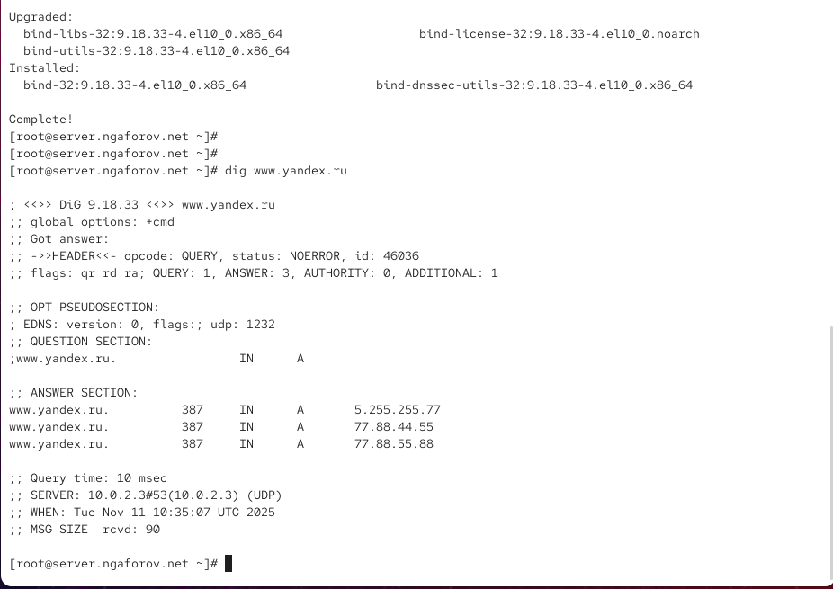

Внешний DNS-запрос

## Анализ конфигурационных файлов

- `/etc/resolv.conf` — DNS сервера по умолчанию.
- `/etc/named.conf` — основной конфигурационный файл BIND.
- `/var/named/*` — шаблоны зон и системные зоны.

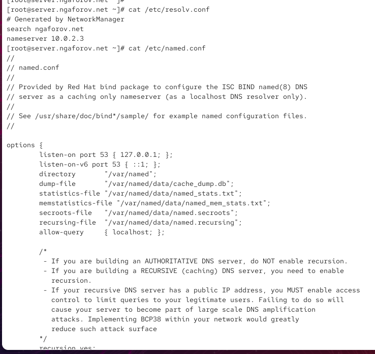

Конфигурация named.conf

## Запуск и проверка DNS-сервера

- DNS-служба запущена и добавлена в автозагрузку.
- Проверен локальный DNS-резолвинг (`dig @127.0.0.1`).

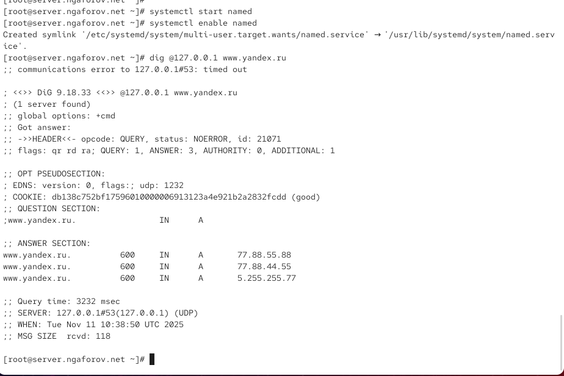

Запрос через локальный DNS

## Назначение DNS-сервера по умолчанию

- Настроено сетевое соединение `eth0` через `nmcli`.
- Установлен DNS: `127.0.0.1`.
- Перезапущен NetworkManager.

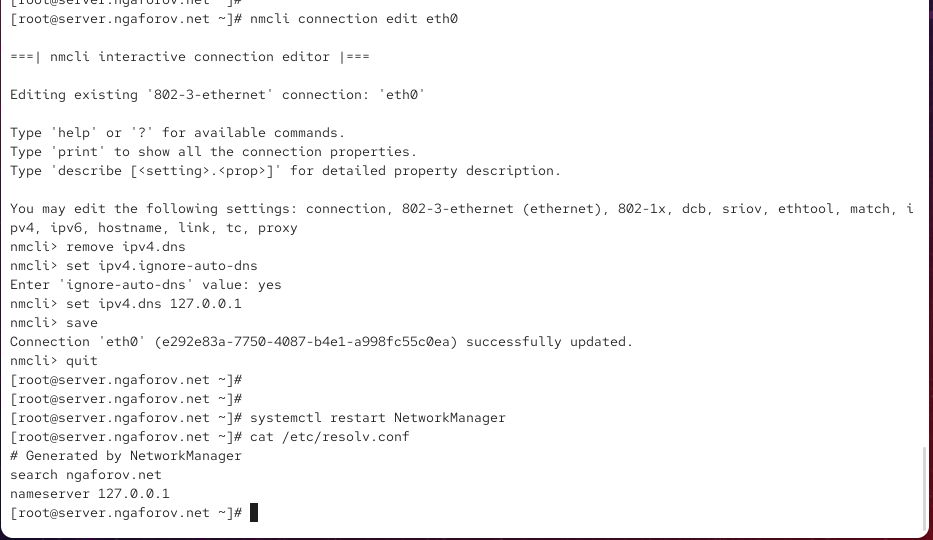

Изменение DNS в nmcli

## Открытие DNS для локальной сети

- В `named.conf` разрешены запросы из сети `192.168.0.0/16`.
- В firewall разрешён сервис DNS.

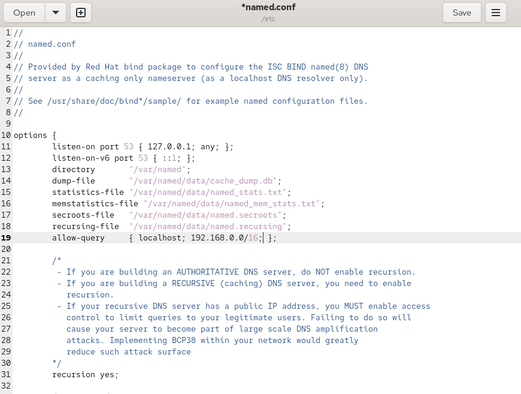

Изменения в named.conf

## Создание файла зон

- Создан новый файл зоны.
- Подключён в `/etc/named.conf`.

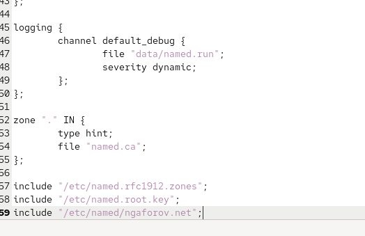

Подключение зоны

## Прямая зона

- Создана зона `ngaforov.net`.
- Добавлены записи: SOA, NS, A.

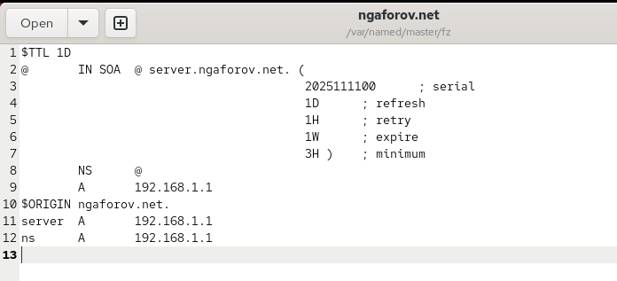

Файл прямой зоны

## Обратная зона

- Создана зона `1.168.192.in-addr.arpa`.
- Добавлены PTR-записи.

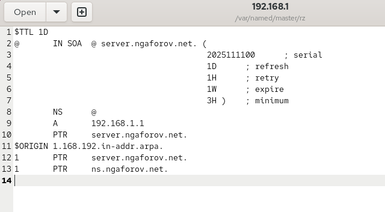

Файл обратной зоны

## SELinux и права доступа

- Исправлены контексты файлов через `restorecon`.
- Разрешена запись в зоны с помощью `setsebool`.

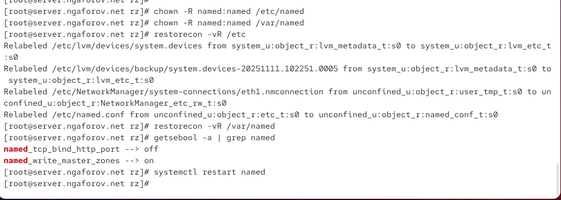

SELinux и права

## Проверка dig и host

- `dig ns.ngaforov.net` — возвращает IP.
- `host -l ngaforov.net` — выводит записи зоны.

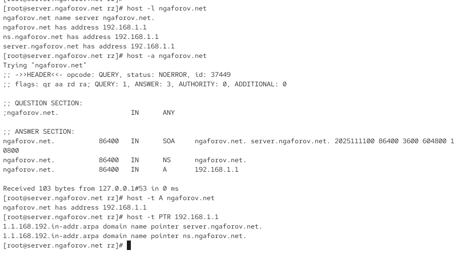

Проверка DNS

## Автоматизация provisioning

- Конфигурационные файлы сохранены в `/vagrant/provision/server/dns`.
- Создан скрипт `dns.sh`, выполняющий автоматическую настройку.

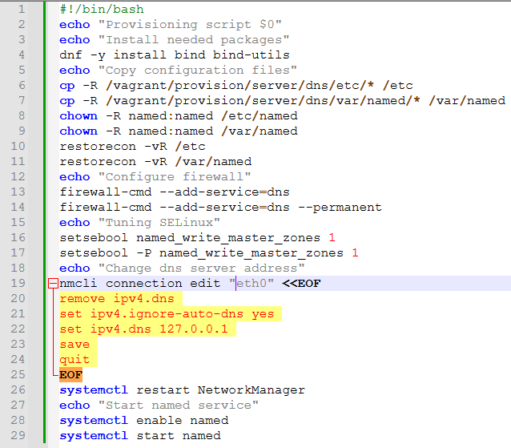

Скрипт provisioning

# Выводы

## Итог работы

- Установлен DNS-сервер BIND.
- Настроены прямые и обратные зоны.
- Проверена работа DNS через `dig` и `host`.
- Выполнена подготовка автоматического provisioning.

DNS-сервер функционирует как **master-сервер зоны** и корректно обрабатывает запросы.